# Take-Home Final Exam Biostatistical computing FALL 2019

Total points: 140 (30% of final grade).

Names: Sumia Tahir

Due: 5:00 pm, Dec 11th, 2019

```r
knitr::opts_chunk$set(echo = TRUE)
library(ggplot2)
suppressMessages(suppressWarnings(library(dplyr)))
library("lars")
library("randomForest")
suppressMessages(library(lme4))
suppressMessages(library(lmerTest))
```

## Instructions (10 pts)

Make sure you read the following. **Failure to follow these instructions may result in points deduction**.

- You only need to submit a knitted HTML file electronically. For all exam questions, please print out your answers so that we can see them in the knitted HTML file. Your procedures (R code) should be displayed as well (usually this is automatic).
- If you generate a figure, please write appropriate figure titles, labels, legends, if necessary.
- If your code is not intuitive, please write comments to make the code readable.
- There is no restriction on which R functions/packages to use, as long as you can answer the questions.
- **You are not allowed to discuss with any other people.** Please email the instructor/TA if you have any clarification questions.
- Don’t forget to put your name on the top of the html page (e.g., Names: ). In addition, rename the html file in the format “2019_PHC6068_Final_YourName.html”, and replace “YourName” with your name.
- **Submission due is 5:00 pm, Dec 11th, 2019 and there is not any grace period for the final exam. If your final exam is not recieved by the due time, it won’t be graded.** Please consider to submit earlier just in case there are any IT technical issues. Or you can at least submit your draft and update your answers later. We will only grade the latest submission.

## Data description.

#### Background

Physical fitness researchers were interested in whether following a new program including both a regimen of exercise and special diet would lead to young men with an interest in weight-lifting to be able to bench press greater amounts of weight and to do it more quickly than if they were to follow only the exercise part of the program alone. Thus, they had a particular interest in the effects of the diet portion of the program.

[figure not shown]

This figure is from https://healthhabits.wordpress.com/marge-simpson-bench-press-2/

To investigate, the researchers recruited 100 young men in high school, college, and beyond with either existing interest and experience with weight-lifting or interest in becoming involved in weight-lifting. It is well-known that the amount of weight a man can bench press may be associated with their body weight, previous weight-lifting experience, and age. Thus, the researchers recorded these baseline characteristics for each man. The men were randomized at the beginning of the study to 2 groups, 50 men per group: (1) Follow the exercise part of the program only; (2) Follow both the exercise and diet parts of the program.

The amount of weight each man was capable of bench pressing at entry into the study was recorded for all men (day 0). Subsequently, the men were allowed to come to the gym at which the study was conducted according to their own schedules, as would be the case in practice. Periodically, members of the research staff would record the amount (lbs) each man was able to bench press (the response). Because each man’s schedule was different due to their class or work obligations, the times at which this was recorded for each man varied across men. Most men were followed for about 9-10 months.

#### Dataset

The prepared data file is available at https://Caleb-Huo.github.io/teaching/data/pressData/benchPress.csv. **Your analysis should be based on this data**.

#### Dataset characteristics

- ID: participant id
- time: in terms of days (since entry into the study) for bench press record
- press: the amount of bench press (in lbs)
- weight: the body weight of the participant at the beginning of study
- age: the age of the participant at the beginning of the study
- prev: indicator for whether the participant has the previous weight lifting experience (0: no; 1: yes)
- diet: indicator for whether the participant is not in the diet program (0) or in the diet program (1)

## Analysis

```r
df <- read.csv ("benchPress.csv", header=T)
head(df)
```

```
##   ID time press weight age pre diet
## 1  1    0 172.0  217.4  22   1    0
## 2  1  154 227.3  217.4  22   1    0
## 3  1  166 230.9  217.4  22   1    0
## 4  1  192 238.7  217.4  22   1    0
## 5  1  287 275.8  217.4  22   1    0
## 6  1  295 278.0  217.4  22   1    0
```

```r
dim(df)
```

```
## [1] 839   7
```

### Question 1. (10 pts)

Plot the individual trajectory of the bench pressed weights (lbs) over time for (a) men in the no diet group and (b) men in the diet group. So there will be two sub-figures, each contains 50 trajectories from the group.

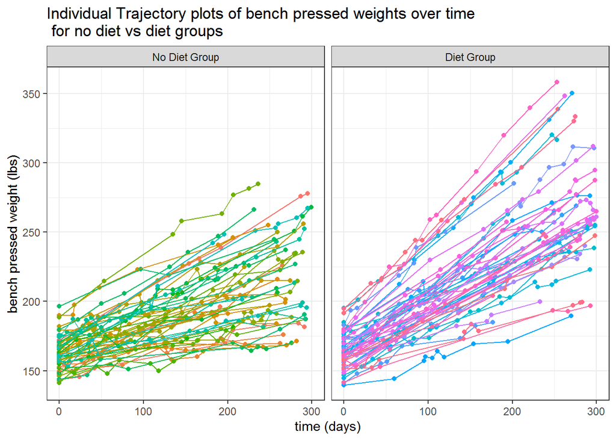

```r
df$ID <- as.factor(df$ID)

labels <- c("0" ="No Diet Group", "1" = "Diet Group")

ggplot(df) +
  aes(x=time, y=press, col=ID) +
  geom_point() +
  geom_path() +
  theme_bw()+
  facet_grid(.~diet, labeller= labeller(diet = labels)) +
  labs(title="Individual Trajectory plots of bench pressed weights over time \n for no diet vs diet groups",
       y="bench pressed weight (lbs)", x="time (days)") +
  theme(legend.position="none")
```

### Question 2. (10 pts)

For each subject, define the improvement of bench press as the difference of the final bench press weight and the initial bench press weight (e.g., $press_{final} - press_{initial}$). We first want to fit a linear regression model using the improvement as outcome variable, body weight, initial age, previous weight lifting experience, diet program, and initial bench press weight as predictors. Print out the coefficient table (e.g., coefficient, standard error, p-value, etc) for all predictors. What is the 95% confidence interval for the diet program? What is the interpretation of the coefficient of the diet?

```r
df_q2 <- df %>%
  arrange(ID, time) %>%
  group_by(ID) %>%
  summarise(weight = weight[1],
            press_ini = press[1],
            age = age[1],
            diet = diet[1],
            pre = pre[1],
            improvement = press[length(press)] - press[1]
            )


lm_q2 <- lm(improvement ~ weight + age + pre + diet + press_ini, data = df_q2)
summary(lm_q2)$coefficients
```

```
##                Estimate Std. Error    t value     Pr(>|t|)
## (Intercept) 19.64238000 45.3979614  0.4326710 6.662449e-01
## weight      -0.01627868  0.1126486 -0.1445085 8.854083e-01
## age         -0.79424299  1.0437389 -0.7609594 4.485860e-01
## pre         27.65084085  7.3842734  3.7445581 3.113252e-04
## diet        42.30859079  5.4520971  7.7600582 1.014420e-11
## press_ini    0.28031828  0.2563191  1.0936302 2.769118e-01
```

```r
confint(lm_q2)["diet",]
```

```
##    2.5 %   97.5 %
## 31.48332 53.13386
```

**Interpretation: On average, with all other variables held fixed, a subject’s improvement in bench press weight would be 42.31(lbs) more in the diet program than the no-diet program.**

### Question 3. (10 pts)

Plot the QQ plot of model residuals. Formally test if the Gaussian assumption for the residuals is violated. In addition, are there any influential points?

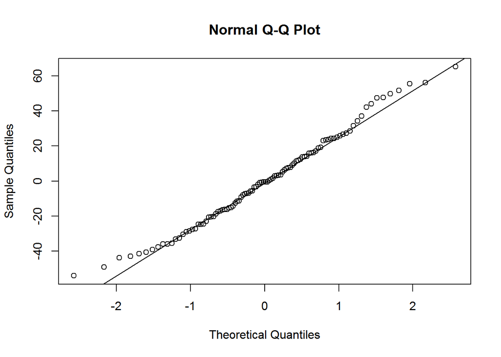

```r
#QQplot of raw residuals

qqnorm(residuals(lm_q2))
qqline(residuals(lm_q2))
```

```r
shapiro.test(residuals(lm_q2))
```

```
##
##  Shapiro-Wilk normality test
##
## data:  residuals(lm_q2)
## W = 0.98672, p-value = 0.4192
```

**The QQ plot shows that the model residuals are normally distributed because they do not deviate significantly from the straight line. The Shapiro-Wilk test is not significant (p > 0.05) which means that the normality assumption is NOT violated.**

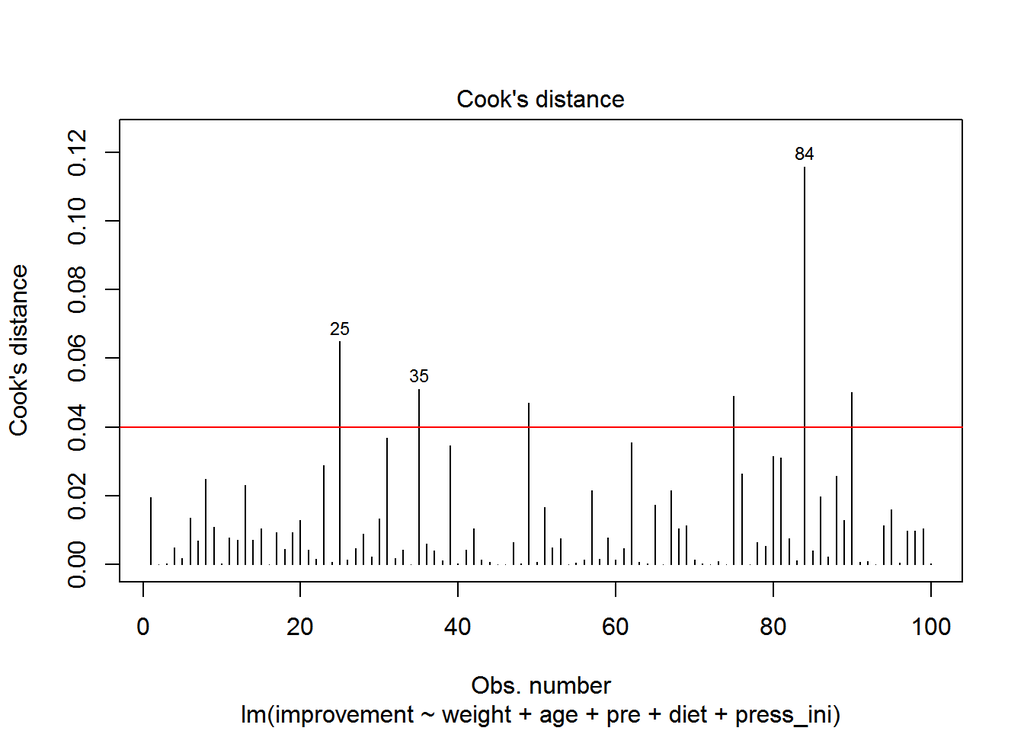

```r
#influential points
n <- nrow(df_q2)
plot(lm_q2, 4)
abline(b = 0, a=4/n, col="red")
```

**The observation IDs of the influential points are:**

```r
names(which(cooks.distance(lm_q2) > 4/n))
```

```
## [1] "25" "35" "49" "75" "84" "90"
```

### Question 4. (10 pts)

Use permutation test to obtain the p-value for the diet program of the same statistical model. Hint: for the permutation test, the null hypothesis is that the distributions of the outcome variable (i.e., improvement in bench press) are the same for the both diet programs. With that being said, under the null, by randomly shuffling the diet program status among all the participants, the null distribution of the coefficient estimate of diet remains the same. Therefore, for each permutation iteration, we can use the coefficient estimate of diet as the test statistic. By permutation $B=1,000$ times, we can get a pool of null test statistics, which will be used as the null distribution of the coefficient estimate of diet. The p-value of diet (we can consider one-sided test) from the permutation test can be obtained by comparing how extreme the observed test statistics is among its null distribution.

```r
T_obs <- coef(lm_q2)["diet"]



B <- 1000

TB <- numeric(B)

for(b in 1:B){
  set.seed(b)
  bdataFrame <- df_q2
  bdataFrame$diet <- sample(bdataFrame$diet)
  lm_b <- lm(improvement ~ weight + age + pre + diet + press_ini, data = bdataFrame)
  TB[b] <- coef(lm_b)["diet"]
}


p_perm <- sum(TB >= T_obs)/B
print(paste("Permutation p-value:", p_perm))
```

```
## [1] "Permutation p-value: 0"
```

**The p-value given by the permutation test is zero which means that the observed statistic is greater than all of the null test statistics; therefore, we reject the null hypothesis that the diet groups have the same distribution. The improvement in bench press weight is not the same in the diet vs no-diet group.**

### Question 5. (10 pts)

Base on the dataset in **Question 2**, standardize variables (including improvement of bench press, body weight, initial age, previous weight lifting experience, diet program, and initial bench press weight) to mean 0 and sd 1. This dataset is referred as **dataset in Question 5**, which will be used in many other questions. Perform lasso regression and visualize the solution path. Again the improvement of bench press is the outcome variable and body weight, initial age, previous weight lifting experience, diet program, and initial bench press weight are predictors. There is an argument “normalize” in lars: set it to be FALSE, so that the covariates won’t be standardized again by lars.

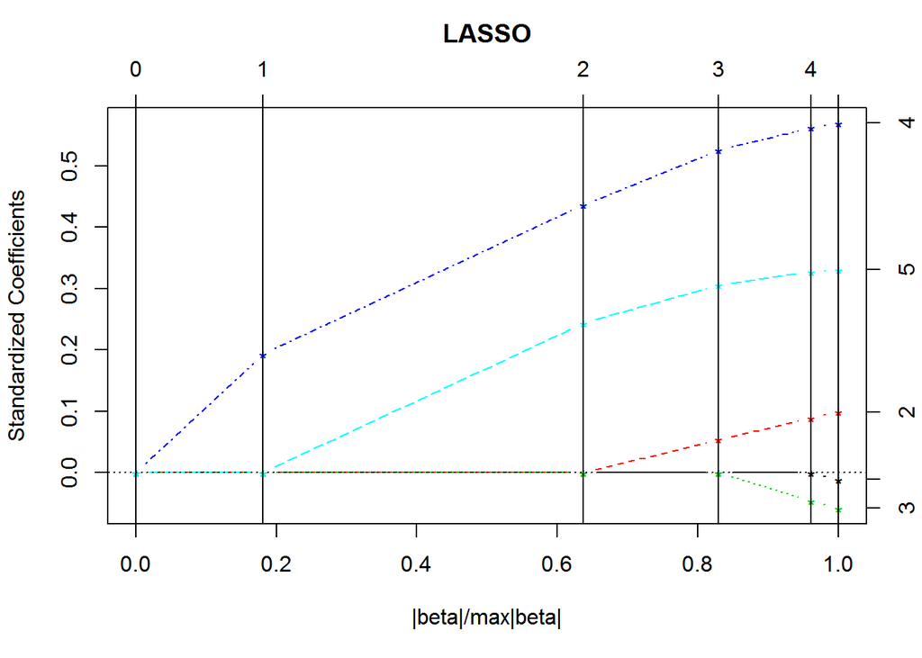

```r
df_q5 <- as.data.frame(cbind(df_q2[,1], scale(df_q2[,-1])))   ## scale all variables except "ID"


x <- as.matrix(df_q5[,2:6])
y <- df_q5[,7]
lassoFit <- lars(x, y, normalize=FALSE)
plot(lassoFit)
```

### Question 6. (10 pts)

We want to investigate the effect of diet using lasso regression. Assume the lasso regression has the Lagrange form $f(\beta) = \frac{1}{2}\|Y - X\beta\| + \lambda\|\beta\|_1$. Let’s pre-specify $\lambda$ in this Lagrange form to be 4 (i.e. $\lambda = 4$). What is the coefficient of diet with lasso Lagrange penalty $\lambda = 4$?

```r
coef_diet0 <- coef(lassoFit, s=4, mode="lambda")["diet"]
coef_diet0
```

```
##      diet
## 0.5337141
```

### Question 7. (10 pts)

Obtain the bootstrapping confidence interval (95%) of the diet program with the same lasso model in the previous question. The number of bootstrapping resampling should be at least $B = 1,000$. Reminder: don’t forget to set normalize = FALSE

```r
B = 1000
n = nrow(df_q5) ## number of obs



b_coef = numeric(B)

for(b in 1:B){
  set.seed(b)
  i = sample(x = 1:n, size = n, replace = TRUE) ## sample indices
  bdata = df_q5[i,] ##new data with resampling
  bx <- as.matrix(bdata[,2:6])
  by <- bdata[,7]
  lassoFit <- lars(bx, by, normalize=FALSE)
  b_coef[b] <- coef(lassoFit, s=4, mode="lambda")["diet"]
}

CI <- quantile(b_coef, c(0.025, 0.975))
CI
```

```
##      2.5%     97.5%
## 0.3889784 0.6720567
```

```r
#alternatively,
#CI_lo <- coef0 - qnorm(0.05/2, lower.tail = FALSE) * sd(b_coef)
#CI_up <- coef0 + qnorm(0.05/2, lower.tail = FALSE) * sd(b_coef)
#c(CI_lo, CI_up)
```

### Question 8. (10 pts)

Based on the problem setting in **Question 5**, perform 10 fold cross validation to select the best tuning parameter $\lambda$ using all samples. Pre-specify the range of $\lambda$ to be $(0,0.1,0.2, \ldots, 15)$. Use mean squared error (MSE) as the criteria make the decision. Visualize the curve of MSE versus $\lambda$. Mark the $\lambda$ with the minimum MSE using a different color in the curve. What is this optimum $\lambda$? Under this $\lambda$, how many covariates will have non-zero coefficient in a model with all subjects? Reminder: don’t forget to set normalize = FALSE

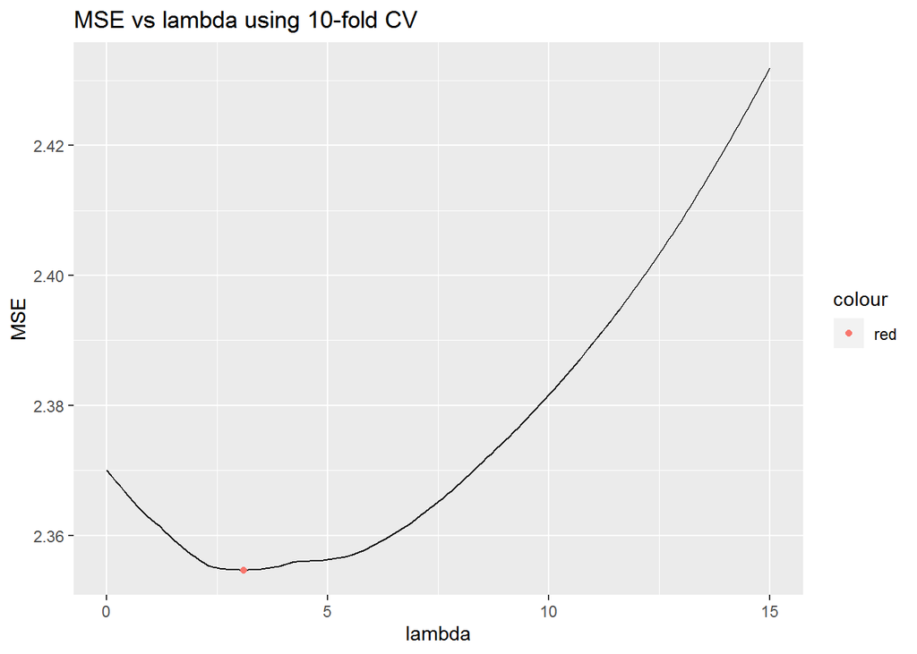

```r
K <- 10
folds <- cut(seq(1,nrow(df_q5)),breaks=K,labels=FALSE)
lambdas <- seq(0,15,0.1)

MSEs <- matrix(NA,nrow=length(lambdas),ncol=K)
rownames(MSEs) <- lambdas
colnames(MSEs) <- 1:K

for(k in 1:K){
  atrainx <- as.matrix(df_q5[!folds==k, 2:6])
  atestx <- as.matrix(df_q5[folds==k,2:6])

  atrainy <- df_q5[!folds==k,7]
  atesty <- df_q5[folds==k,7]

  klassoFit <- lars(atrainx, atrainy, normalize=FALSE)

  predictValue <- predict.lars(klassoFit, atestx, s=lambdas, type="fit",  mode="lambda")
  MSE <- apply(predictValue$fit,2, function(x) sqrt(sum((x - atesty)^2)))

  MSEs[,k] <- MSE
}

MSEdataFrame <- data.frame(lambda=lambdas, MSE = rowMeans(MSEs))
ggplot(MSEdataFrame) + aes(x=lambda, y = MSE) + geom_path() + ggtitle("MSE vs lambda using 10-fold CV") +
  geom_point(data=MSEdataFrame[which.min(MSEdataFrame$MSE),], aes(x=lambda, y=MSE, col="red"))
```

```r
opt_lambda <- with(MSEdataFrame, lambda[which.min(MSE)])
print(paste("Optimum lambda:", opt_lambda))
```

```
## [1] "Optimum lambda: 3.1"
```

```r
nonzero <- length(which(coef(lassoFit, s=opt_lambda, mode="lambda") != 0))

print(paste("Number of covariates with non-zero coefficient:", nonzero))
```

```
## [1] "Number of covariates with non-zero coefficient: 5"
```

### Question 9. (10 pts)

Based the **dataset in Question 5**, we want to build a random forest classifier to predict improvement in bench press. The predictors inlcude body weight, initial age, previous weight lifting experience, diet program, and initial bench press weight. Plot the importance score of all predictors using barplot. Which predictor has the largest importance score?

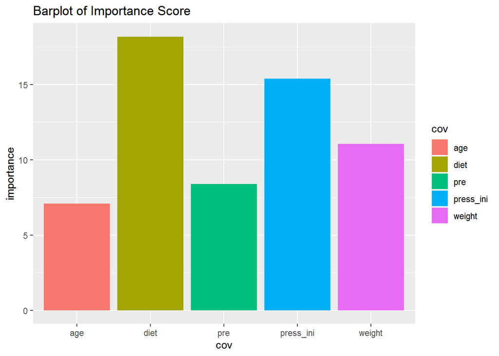

```r
rfit <- randomForest(improvement ~ . -ID, data = df_q5)
imp <- importance(rfit)
impData <- data.frame(cov = rownames(imp), importance=imp[,1])

ggplot(impData) + aes(x=cov, y=importance, fill=cov) + geom_bar(stat="identity") + ggtitle("Barplot of Importance Score")
```

**The predictor Diet has the largest importance score.**

### Question 10. (10 pts)

Based on previous question, define fitted improvement as the predicted value of the training data using the random forest classifier. Draw scatter plot of fitted improvement and actual improvement. Mark the Pearson correlation coefficient in the figure title.

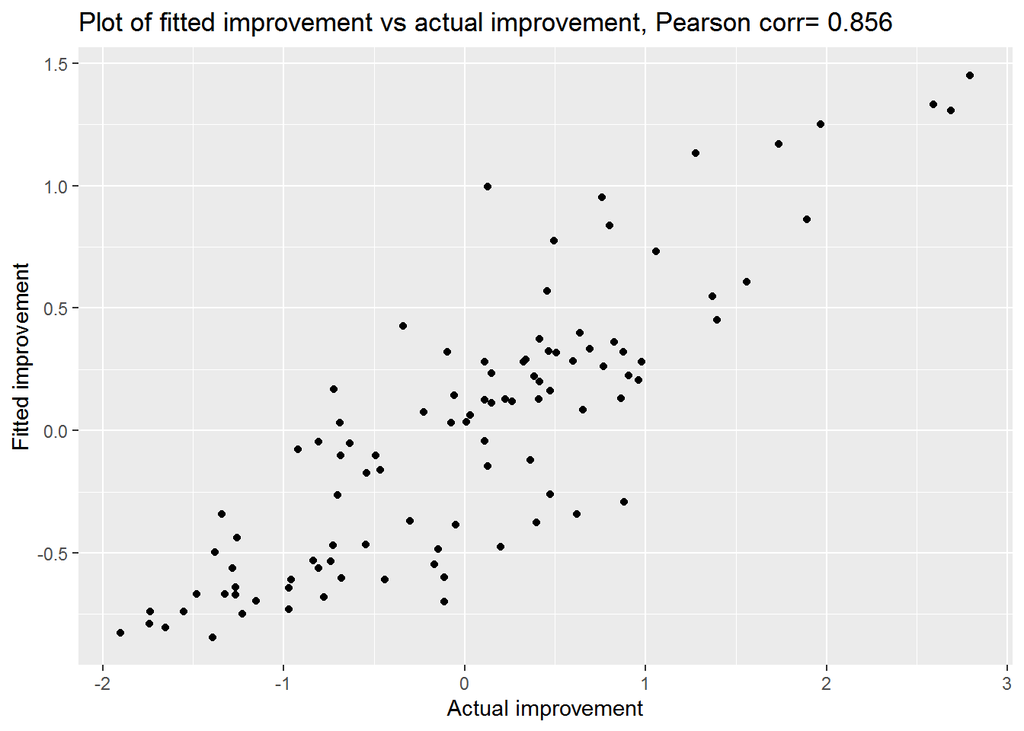

```r
fitted_imp <- predict(rfit, df_q5)
x <- df_q5$improvement
y <- fitted_imp
pcor <- cor(x, y, method="pearson")
ggplot(df_q5) +  aes(x, y) + geom_point() +
  labs(title=paste("Plot of fitted improvement vs actual improvement, Pearson corr=", round(pcor,3)), y="Fitted improvement", x="Actual improvement")
```

### Question 11. (10 pts)

Now, we consider a model involving longitudinal change of press weight (time to be treated as continuous) and diet. Assume the mean time slope is different for different diet groups, and we allow each participant’s individual linear trajectory to vary from the mean population linear trajectory, and initial bench press weight to vary from the mean population baseline. In addition, baseline weight, age, weight lifting experience, and initial bench press weight may influence the longitudinal outcome trajectory. What is the difference between the slope of the diet group and no diet group? What is its p-value?

```r
df_q11 <- df %>%
  left_join(df_q2 %>% dplyr::select(ID, press_ini))
df_q11$time <- as.numeric(df_q11$time)
df_q11$diet <- as.factor(df_q11$diet)
df_q11$pre <- as.factor(df_q11$pre)


q11_fit <- lmer(press ~ time*diet + (1 + time|ID) + weight + age + pre + press_ini, data=df_q11)
```

```r
summary(q11_fit)$coef["diet1", c("Estimate", "Pr(>|t|)")]
```

```
##    Estimate    Pr(>|t|)
## -1.33110778  0.01783737
```

### Question 12. (10 pts)

We want to visualize the mean trajectories over time for both diet group and no diet group. Since the times at which bench press was recorded for each man varied across men, we will only plot three time points: day 0, day 150, and day 300. If there are no days that match exactly day 0, day 150 and day 300, we can use their closest days to replace. Use different colors to indicate diet/no diet groups. Mark standard error bars at the mean estimates of all these three time points. Everything should be within one figure.

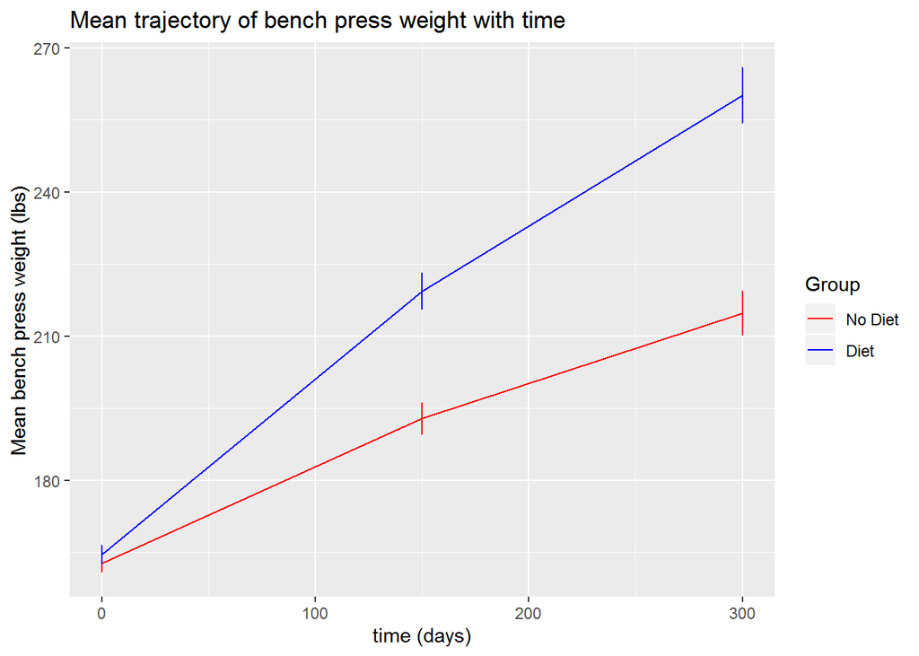

```r
df_q12 <- df_q11 %>%
    group_by(ID) %>%
    slice(which.min(abs(time - 0)),
          which.min(abs(time - 150)),
          which.min(abs(time - 300)))

df_q12b <- df_q12 %>%
    group_by(ID) %>%
     mutate(time = replace(time, c(1,2,3), c(0, 150, 300)))


df_q12b %>%
    group_by(diet, time) %>%
    summarize(mean=mean(press), se=sd(press)/sqrt(n())) %>%
      ggplot() +
      aes(x=time, y=mean, color=diet) +
      geom_path() +
      geom_errorbar(aes(ymin=mean-se, ymax=mean+se),
          size=0.5, width=.2) +
      labs(title= "Mean trajectory of bench press weight with time",
           y = "Mean bench press weight (lbs)",
           x = "time (days)") +
           scale_color_manual(name="Group", labels=c("No Diet","Diet"),
                       values=c("red","blue"))
```

### Question 13. (10 pts)

Formally test whether the random slope term is necessary in **Question 11**.

```r
### random slope term = (time|ID)

q11_fit <- lmer(press ~ time*diet + (1 + time|ID) + weight + age + pre + press_ini, data=df_q11, REML=FALSE)
q11_fit0 <- lmer(press ~ time*diet + (1|ID) + weight + age + pre + press_ini, data=df_q11, REML=FALSE)
anova(q11_fit, q11_fit0)
```

```
## Data: df_q11
## Models:
## q11_fit0: press ~ time * diet + (1 | ID) + weight + age + pre + press_ini
## q11_fit: press ~ time * diet + (1 + time | ID) + weight + age + pre +
## q11_fit:     press_ini
##          Df    AIC    BIC  logLik deviance  Chisq Chi Df Pr(>Chisq)
## q11_fit0 10 6604.2 6651.5 -3292.1   6584.2
## q11_fit  12 5134.4 5191.1 -2555.2   5110.4 1473.8      2  < 2.2e-16 ***
## ---
## Signif. codes:  0 '***' 0.001 '**' 0.01 '*' 0.05 '.' 0.1 ' ' 1
```

**The p-value is very significant (< 2.2e-16); therefore, the random slope term is necessary.**